# An Analysis on the Impacts of Extreme Poverty Rates on Life Expectancy

Author

Bernardo Lopez, Victor Zahn, Gregory Morita, Jonathan Garcia

```r
library(tidyverse)
library(knitr)
library(kableExtra)
library(gt)
library(broom)
library(gtsummary)
library(ggplot2)
library(gganimate)
library(gapminder)
library(gifski)
```

## Introduction

Life expectancy varies drastically across nations and time. While life expectancy is on the rise, the gap in wealth inequality across nations means life-saving and quality-of-life care are similarly unequal. One way to measure this inequality is in the proportion of a nation’s population that lives in the lowest levels of poverty. These populations are likely to lack access to public or private healthcare, which we believe will be a strong contributing factor to their nations’ life expectancy.

This report takes a look at the connection between the extent of extreme poverty in 190+ nations and their respective life expectancy, The report covers 300 years of data from 1800 to independently projected values up to the year 2100. The condition for falling under “Extreme poverty” is for populations with income <$2.15 a day (inflation adjusted).

All data comes from two independent datasets (courtesy of Gapminder) that will be cleaned and joined together for analysis. Our full code can be found at https://github.com/BLopez04/331GroupS

The first dataset is the “Extreme poverty rate (<$2.15/day, Gapminder data) long series 1800 to 2100”.

```r
poverty_unclean <- read.csv("./Data/gm_epov_rate.csv")
```

The second is the “Life expectancy (The number of years a newborn infant would live if the current mortality rates at different ages were to stay the same throughout its life.)”

```r
expectancy_unclean <- read.csv("./Data/lex.csv")
```

## Data Cleaning

Cleaning the data requires getting rid of country/year pairs with no data in either the poverty rate or life expectancy datasets. This leads to 794 country/year pairs being removed out of 57,792 from the poverty dataset.

```r
poverty_unclean |>
  pivot_longer(cols = "X1800":"X2100",
               names_to = "year",
               values_to = "poverty_rate") |>
  str()

poverty_unclean |>
  pivot_longer(cols = "X1800":"X2100",
               names_to = "year",
               values_to = "poverty_rate") |>
  map_int(~ sum(is.na(.x))) |>
  enframe(name = "var", value = "missing")
```

[output not shown]

The life expectancy dataset ends up with 1,500/58,996 missing country/year pairs with the added condition of having a life expectancy greater than 0 in each data point. We believe both data cleaning steps should have minimal impact on analyzing greater trends.

```r
expectancy_unclean |>
  pivot_longer(cols = "X1800":"X2100",
               names_to = "year",
               values_to = "life_expectancy") |>
  str()

  expectancy_unclean |>
  pivot_longer(cols = "X1800":"X2100",
               names_to = "year",
               values_to = "life_expectancy") |>
  map_int(~ sum(is.na(.x))) |>
  enframe(name = "var", value = "missing")
```

[output not shown]

```r
poverty <- poverty_unclean |>
  pivot_longer(cols = "X1800":"X2100",
               names_to = "year",
               values_to = "poverty_rate") |>
  filter(!is.na(poverty_rate)) |> # Gets rid of rows with no data
  mutate(year = as.numeric(str_extract(year, pattern = "[:digit:]{4}")), # Extract years
         poverty_rate = poverty_rate/100) # Convert rates to range 0-1

expectancy <- expectancy_unclean |>
  pivot_longer(cols = "X1800":"X2100",
               names_to = "year",
               values_to = "life_expectancy") |>
  filter(!is.na(life_expectancy) & life_expectancy > 0) |> # Get rid of rows with no data (and 0 seems extreme)
  mutate(year = as.numeric(str_extract(year, pattern = "[:digit:]{4}"))) # Extract years
```

The rest of the data cleaning adapts the sets to be more workable, and the data Joining is done between the two datasets on country/year pairs with both poverty and life expectancy data.

```r
combined <- poverty |>
  full_join(expectancy, join_by(country == country, year == year)) |>
  drop_na()
```

**Hypothesis**

## Modeling the Relationship between extreme poverty rate and life expectancy at birth

# Data Visualizations

To explore the relationship between poverty rate and life expectancy, we start with a scatterplot of the average values for each country across all years. Each point represents a country, with notable outliers labeled. This plot highlights a general trend where countries with higher average poverty rates tend to have lower average life expectancy.The animated plot shows us how this relationship changes over time. We see that across time as poverty rate decreases, life expectency trends towards increasing.

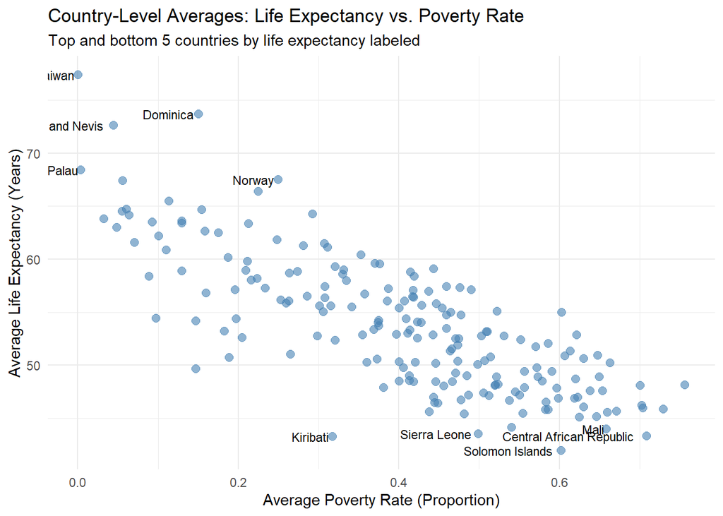

```r
if (!exists("summarized")) {
  summarized <- combined |>
    group_by(country) |>
    summarise(
      avg_poverty_rate = mean(poverty_rate, na.rm = TRUE),
      avg_life_expectancy = mean(life_expectancy, na.rm = TRUE)
    )
}
top_bottom <- summarized |>
  arrange(avg_life_expectancy) |>
  slice(c(1:5, (n() - 4):n()))

ggplot(summarized, aes(x = avg_poverty_rate, y = avg_life_expectancy)) +
  geom_point(color = "steelblue", alpha = 0.6, size = 2.5) +
  geom_text(data = top_bottom, aes(label = country), hjust = 1.1, size = 3) +
  labs(
    title = "Country-Level Averages: Life Expectancy vs. Poverty Rate",
    subtitle = "Top and bottom 5 countries by life expectancy labeled",
    x = "Average Poverty Rate (Proportion)",
    y = "Average Life Expectancy (Years)"
  ) +
  theme_minimal()
```

```r
animated_plot <- ggplot(combined, aes(x = poverty_rate, y = life_expectancy)) +
  geom_point(aes(color = country), alpha = 0.6, show.legend = FALSE) +
  geom_smooth(method = "lm", se = FALSE, color = "black") +
  labs(
    title = "Year: {frame_time}",
    subtitle = "Tracking poverty vs. life expectancy over time",
    x = "Poverty Rate (Proportion)",
    y = "Life Expectancy (Years)"
  ) +
  transition_time(as.integer(year)) +
  ease_aes('linear') +
  theme_minimal()

animate(animated_plot, renderer = gifski_renderer("poverty_vs_lifeexp.gif"),
        width = 800, height = 500,  fps = 5, duration = 10)
```

[figure not shown]

# Linear Regression

Here we fit a linear regression model using the average poverty rate and life expectancy for each country across all years in the dataset (1800-2100). Each point is a single country in the scatterplot.

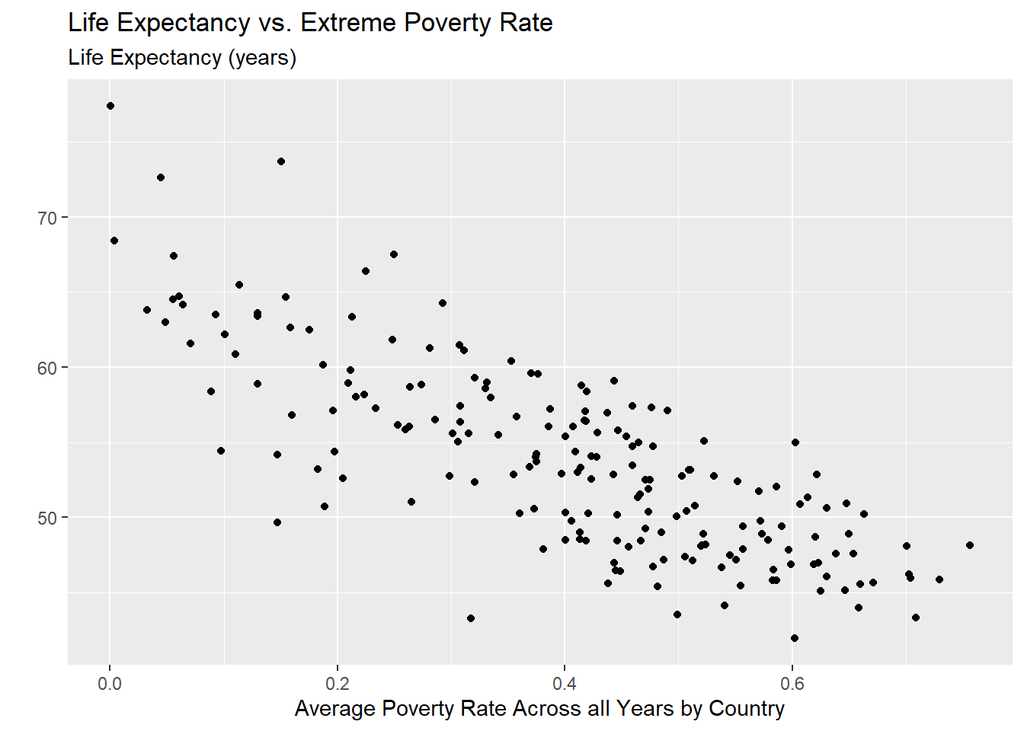

```r
summarized <- combined |>
  group_by(country) |>
  summarise(
    avg_poverty_rate = mean(poverty_rate, na.rm = TRUE),
    avg_life_expectancy = mean(life_expectancy, na.rm = TRUE))

summarized |>
  ggplot(aes(x = avg_poverty_rate, y = avg_life_expectancy)) +
  geom_point() +
  geom_smooth(method = "lm") |>
  labs(x = "Average Poverty Rate Across all Years by Country",
       y = "",
       subtitle = "Life Expectancy (years)",
       title = "Life Expectancy vs. Extreme Poverty Rate")
```

```r
summarized_lm <- lm(data = summarized, avg_life_expectancy ~ avg_poverty_rate)

summarized_lm |>
  tbl_regression(intercept = T, label = list(avg_poverty_rate = "Average Poverty Rate")) |>
    kable(caption = "Coefficient
        values returned by the fitted
        linear regression model",
        col.names = c("Characteristic",
                      "Estimated Value",
                      "95% Confidence Interval",
                      "P Value")) |>
  kable_styling(full_width = F,
                html_font = "Cambria",
                bootstrap_options = "striped",
                position = "center")
```

Coefficient values returned by the fitted linear regression model

| Characteristic | Estimated Value | 95% Confidence Interval | P Value |
| --- | --- | --- | --- |
| (Intercept) | 65 | 64, 67 | <0.001 |
| Average Poverty Rate | -29 | -32, -26 | <0.001 |

**Interpretation of Returned Coefficient Values**

Alongside these values, both the P-value and 95% confidence intervals are reported. The reported P-values for both characteristics being so incredibly low means that the results and relationships displayed by the linear model are *very* statistically relevant. This means that the predictions returned by the model are unlikely to be caused by any sampling errors or random chance. Likewise, the 95% confidence interval reported gives us a range in which 95% of samples would have average values for the given characteristics lying within that range.

# Model Fit

```r
# variances
response_variance <- var(summarized$avg_life_expectancy, na.rm = TRUE)  # A
fitted_variance <- var(fitted(summarized_lm))                            # B
residual_variance <- var(residuals(summarized_lm))
r_squared_manual <- fitted_variance / response_variance

#table

tibble(
  `Measure` = c(
    "Variance in response ",
    "Variance in fitted values",
    "Variance in residuals",
    "R²"
  ),
  `Value` = c(
    response_variance,
    fitted_variance,
    residual_variance,
    r_squared_manual
  )
) |>
  gt() |>
  fmt_number(columns = "Value", decimals = 4) |>
  tab_header(
    title = "Model Variance Summary"
  ) |>
  cols_label(
    Measure = "Descriptive Statistic",
    Value = "Value"
  )
```

Model Variance Summary

| Descriptive Statistic | Value |
| --- | --- |
| Variance in response | 40.8622 |
| Variance in fitted values | 25.2864 |
| Variance in residuals | 15.5757 |
| R² | 0.6188 |

**Interpretation of Model Variability**

The model accounts for 61.88% of variability in average life expectancy for each country across all years in the dataset (1800-2100). This suggest that poverty rate is a strong indicator for life expectancy. The model seems to capture a large amount of variance but other variables or interactions may improve model accuracy.

# Cross Validation

We used a K-fold cross-validation to evaluate the fit of our regression model. A random seed was set to ensure that the data split is consistent each time the code is run, improving reproducibility. Based on the size of the dataset, we determined that using approximately 10 observations per fold was appropriate. Observations were then randomly assigned to one of the folds.

A custom K-fold function was created to perform the cross-validation process. For each fold, the data was split into a training set and a test set. The training set was used to fit a linear regression model predicting average life expectancy based on poverty rate. This model was then applied to the test set, and an R2 was calculated to measure how well the model explained variation in the test fold. This process was repeated for each fold, providing an estimate of model performance across the entire dataset.

```r
set.seed(192)
# n as amount of rows in data
n <- nrow(summarized)
# k such that each sample size is >=10
k <- floor(n/10)

# randomly partition into k folds (19 for our data)
summarized <- summarized |>
  mutate(fold = sample(rep_len(1:k, length.out = n),
                       size = n))

kfold <- function(data, fold_num) {
  # Separate out data from this fold
  fold_data <- data |>
    filter(fold == fold_num)
  # Use the rest of the data to train our model
  training_data <- data |>
    filter(fold != fold_num)

  # Fit our model using just the training data
  train_lm <- lm(data = training_data, avg_life_expectancy ~ avg_poverty_rate)

  # Generate predictions for the separated fold data
  fold_predictions <- predict(train_lm, newdata = fold_data)

  # Calculate R^2 for the separate fold data and return it
  fold_r2 <- var(fold_predictions)/
    var(fold_data$avg_life_expectancy)
  return(fold_r2)

}

# map the function to our folded data
res <- map_dbl(1:k,
               ~ kfold(summarized, .x))
```

**Plotting these results**

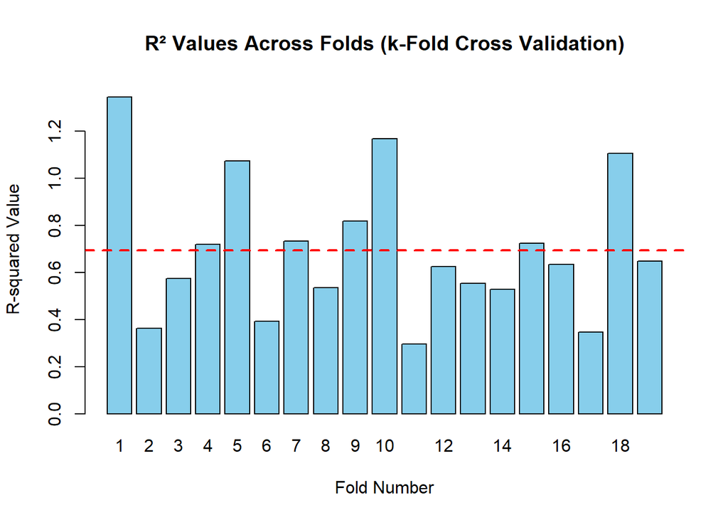

```r
# plot R^2 for each fold
barplot(
  res,
  names.arg = 1:length(res),
  col = "skyblue",
  main = "R² Values Across Folds (k-Fold Cross Validation)",
  xlab = "Fold Number",
  ylab = "R-squared Value",
  ylim = c(0, max(res) + 0.05)
)

# draw average R^2 line
abline(h = mean(res), col = "red", lty = 2, lwd = 2)
```

**Interpretation of k-fold Cross Validation R^2 Values**

The average R<sup>2</sup> value for our K-fold cross validation was 0.6948737 meanwhile, the R<sup>2</sup> value for our fitted model was 0.6188226. This may suggest that the linear regression model is underfitting. This may also be indicative of the difference in how the R<sup>2</sup> values were calculated for both our fitted model and the k-fold cross validation. In our implementation of the K-fold algorithm that we used, the equation to calculate R<sup>2</sup> values allowed for values over 1, which is outside the typical range of [0,1] for R<sup>2</sup> values. This may have resulted in the average R<sup>2</sup> value for our k-fold cross validation to be higher than it should be, as is indicated by the far higher R<sup>2</sup> values for some folds rather than others. Fold variance mostly seems to been around the aveerage value, with some notable outliers such as folds 1, 2, 5, 6, 10, 11, 17, and 18.

The predictiveness of our model seems to suffice for our dataset which is primarily focused on poverty’s relation to lifespan. This is based on the fact that an article found in the Scholastica academic journal stated that, “The field of finance has a much larger range with “good” R2 values ranging from 0.40 to 0.70, depending on the nature of the analysis and data availability” (Gupta et al. 2024). As poverty is based on a myriad of financial and sociological factors, an R<sup>2</sup> value of ~0.6 seems to be indicative of good predictiveness for our model.

# Conclusion

This analysis supports the hypothesis that higher poverty rates are strongly associated with lower life expectancy across 190 countries from 1800 to 2100. The linear regression model explained 61.88% of the variation in life expectancy and identified poverty rate as a significant predictor, with a p-value less than 0.001. While the model fit this dataset well, the variability observed across folds in the k-fold cross-validation suggests that the model’s performance may fluctuate depending on the data subset. This indicates that incorporating additional variables could improve model accuracy and generalization to other datasets. Overall, the results highlight a clear and significant inverse relationship between poverty rate and life expectancy in this particular historical data examined.

# References

Gupta, Avi, et al. “Determining a Meaningful R-Squared Value in Clinical Medicine.” Academic Medicine & Surgery, 27 Oct. 2024, academic-med-surg.scholasticahq.com/article/125154-determining-a-meaningful-r-squared-value-in-clinical-medicine, https://doi.org/10.62186/001c.125154.